(ticinosade)=

# Ticino

English

**Unten:** Karte des Erhebungsgebiets März 2020 - Mai 2021. Durchmesser der Punktsymbole = das mittlere Erhebungsergebnis in gefundene Abfallobjekte pro 100 Meter (p/100m).

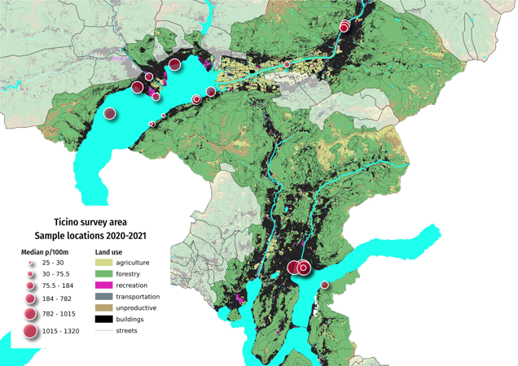

## Erhebungsorte und Landnutzungsmerkmale

```
28
28
```

*Seen:*

> Lago Maggiore, Lago di Lugano

*Flüsse:*

> Cassarate, Maggia, Ticino

*Gemeinden:*

> Ascona, Bellinzona, Brissago, Gambarogno, Locarno, Lugano, Minusio

### Landnutzungsprofil der Erhebungsorte

Die Landnutzung wird als Prozentsatz der Gesamtfläche angegeben, die jeder Landnutzungskategorie innerhalb eines Radius von 1'500 m um den Erhebungsort zugeordnet wird.

Straßen werden als Gesamtzahl der Straßenkilometer im Umkreis von 1'500 m angegeben. Flussmündung ist ebenfalls eine ordinale Rangfolge der Anzahl der Flüsse/Kanäle, die einen See innerhalb von 1'500 m um den Erhebungsort herum durchqueren.

Das Verhältnis der Anzahl der Erhebungen bei unterschiedlichen Landnutzungsprofilen gibt einen Hinweis auf die ökologischen und wirtschaftlichen Rahmenbedingungen der Untersuchungsstandorte.

Für weitere Informationen *Landnutzungsprofil*.

**Unten:** Landnutzungsprofil der Erhebungsorte. Verteilung der Erhebungen in Bezug auf die Landnutzung.

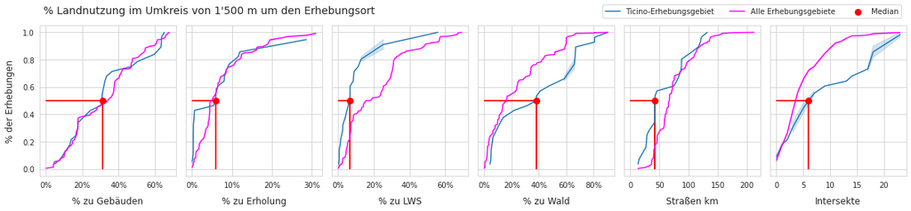

### Kumulative Gesamtmengen nach Gewässer

**Unten:** Die kumulierten Gewichte und Merkmale für das Ticino-Erhebungsgebietund dessen Gewässer.

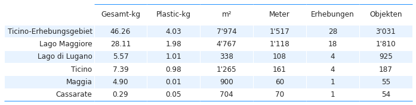

### Verteilung der Ergebnisse der Datenerhebungen

**Links:** Ticino-Erhebungsgebiet, 03.2020 bis 05.2021, n=28. Werte größer als 1'551 p/100m werden nicht gezeigt. **Rechts:** Ticino-Erhebungsgebiet empirische kumulative Verteilung der Datenerhebunge.

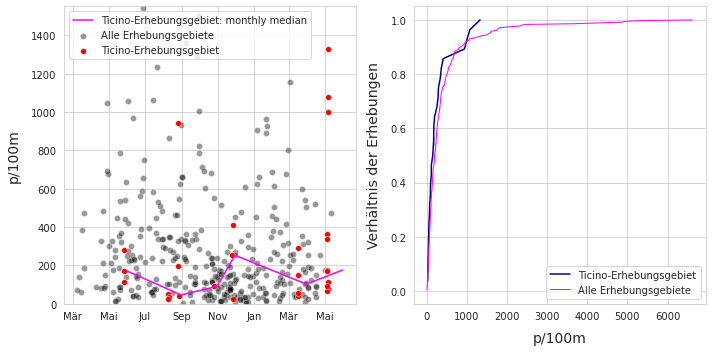

### Zusammengefasste Daten und Materialarten

**Links:** Zusammenfassung der Daten aller Erhebungen im Ticino-Erhebungsgebiet. **Rechts:** Gefundene Materialarten im Ticino-Erhebungsgebiet und Prozentsatz deren Gesamtmenge.

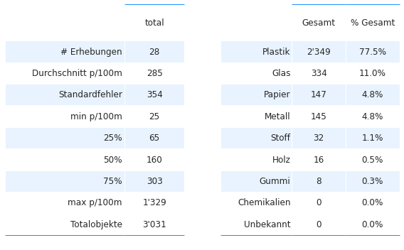

## Die am häufigsten gefundenen Objekte

Die am häufigsten gefundenen Objekte sind die zehn mengenmäßig am meisten vorkommenden Objekte UND/ODER Objekte, die in mindestens 50% aller Datenerhebungen identifiziert wurden (fail-rate).

**Unten:** Häufigste Objekte im Ticino-Erhebungsgebiet: fail-rate >/= 50% und/oder Top Ten nach Anzahl. Zusammengenommen machen die häufigsten Objekte 74% aller gefundenen Objekte aus. Anmerkung: p/100m = Medianwert der Erhebung.

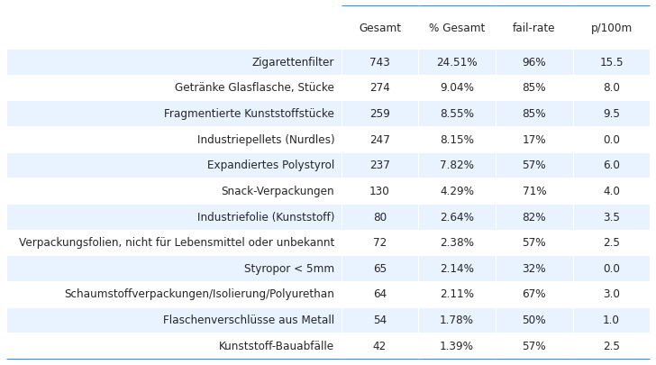

### Die am häufigsten gefundenen Objekte nach Gewässer

**Unten:** häufigste Objekte im Ticino-Erhebungsgebiet: Median p/100m.

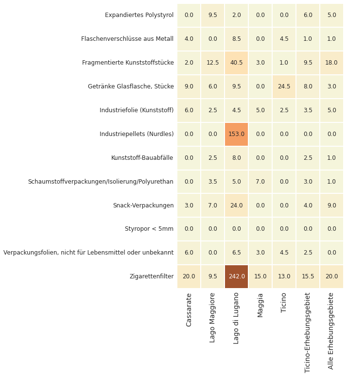

### Die am häufigsten gefundenen Objekte im monatlichen Durchschnitt

**Unten:** Ticino-Erhebungsgebiet, monatliche Durchschnittsergebnisse p/100m.

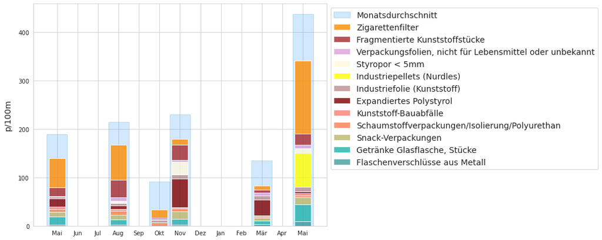

## Ergebnisse der Datenerhebungen und Landnutzung

Der Flächennutzungsmix ist eine einzigartige Darstellung der Art und des Umfangs der wirtschaftlichen Aktivität und der Umweltbedingungen rund um den Erhebungsort. Die Schlüsselindikatoren aus den Ergebnissen der Datenerhebungen werden mit den Flächennutzungsraten für einen Radius von 1500 m um den Erhebungsort verglichen.

Eine Assoziation ist eine Beziehung zwischen den Ergebnissen der Datenerhebungen und dem Landnutzungsprofil, die nicht auf Zufall beruht. Das Ausmaß der Beziehung ist weder definiert noch linear.

Die Rangkorrelation ist ein nicht-parametrischer Test, um festzustellen, ob ein statistisch signifikanter Zusammenhang zwischen der Landnutzung und den bei einer Abfallobjekte-Erhebung identifizierten Objekten besteht.

Die verwendete Methode ist der Spearman’s rho oder Spearmans geordneter Korrelationskoeffizient. Die Testergebnisse werden bei p<0,05 für alle gültigen Erhebungen an Seen im Untersuchungsgebiet ausgewertet.

1. Rot/Rosa ist eine positive Assoziation
2. Gelb ist eine negative Assoziation
3. Weiß ist keine statistische Grundlage für die Annahme eines Zusammenhangs, p>0,05

*Ausgewertete Korrelation der am häufigsten gefundenen Objekte in Bezug auf das Landnutzungsprofil im Ticino-Erhebungsgebiet. Für alle gültigen Seerhebungen n=22.*

*Da es weniger als 100 Erhebungen gibt, ist Vorsicht geboten. Erhebungen über Strand-Abfallobjekte weisen eine große Streuung auf!*

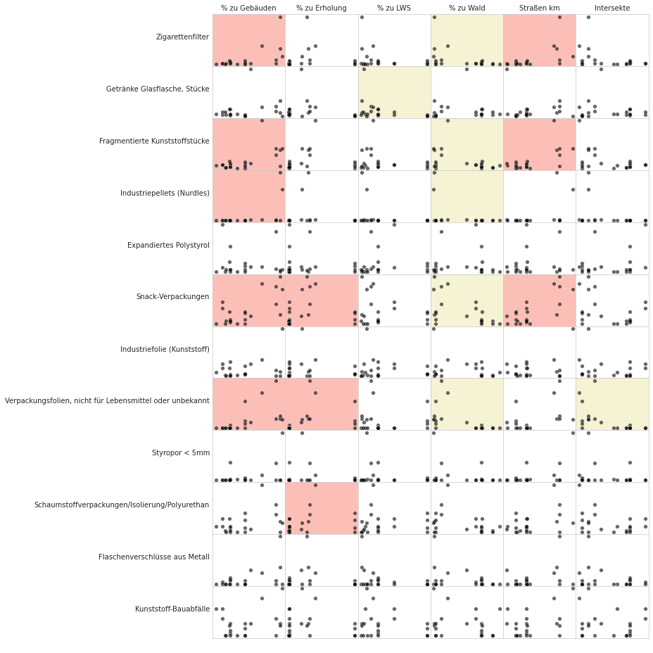

*Legende: wenn p >0,05 = weiß, wenn p < 0,05 und rho > 0 = rot, wenn p < 0,05 und rho < 0 = gelb*

## Verwendungszweck der gefundenen Objekte

Die Nutzungsart basiert auf der Verwendung des Objekts, bevor es weggeworfen wurde, oder auf der Artikelbeschreibung, wenn die ursprüngliche Verwendung unbestimmt ist. Identifizierte Objekte werden einer der 260 vordefinierten Kategorien zugeordnet. Die Kategorien werden je nach Verwendung oder Artikelbeschreibung gruppiert.

- **Abwasser:** Gegenstände, die aus Kläranlagen freigesetzt werden, einschließlich Gegenstände, die wahrscheinlich über die Toilette entsorgt werden
- **Mikroplastik (< 5 mm):** fragmentierte Kunststoffe und Kunststoffharze aus der Vorproduktion
- **Infrastruktur:** Artikel im Zusammenhang mit dem Bau und der Instandhaltung von Gebäuden, Straßen und der Wasser-/Stromversorgung
- **Essen und Trinken:** alle Materialien, die mit dem Konsum von Essen und Trinken in Zusammenhang stehen
- **Landwirtschaft:** z. B. für Mulch und Reihenabdeckungen, Gewächshäuser, Bodenbegasung, Ballenverpackungen. Einschliesslich Hartkunststoffe für landwirtschaftliche Zäune, Blumentöpfe usw.
- **Tabak:** hauptsächlich Zigarettenfilter, einschließlich aller mit dem Rauchen verbundenen Materialien
- **Freizeit und Erholung:** Objekte, die mit Sport und Freizeit zu tun haben, z. B. Angeln, Jagen, Wandern usw.
- **Verpackungen außer Lebensmittel und Getränke:** Verpackungsmaterial, das nicht lebensmittel-, getränke- oder tabakbezogen ist
- **Plastikfragmente:** Plastikteile unbestimmter Herkunft oder Verwendung
- **Persönliche Gegenstände:** Accessoires, Hygieneartikel und Kleidung

Im Anhang finden Sie die vollständige Liste der identifizierten Objekte, einschließlich Beschreibungen und Gruppenklassifizierung. Der Abschnitt Code-Gruppen beschreibt jede Codegruppe im Detail und bietet eine umfassende Liste aller Objekte in einer Gruppe.

**Unten:** Verwendungszweck oder Beschreibung der identifizierten Objekte in % der Gesamtzahl nach Gewässer im Ticino-Erhebungsgebiet. Fragmentierte Objekte, die nicht eindeutig identifiziert werden können, werden weiterhin nach ihrer Grösse klassifiziert.

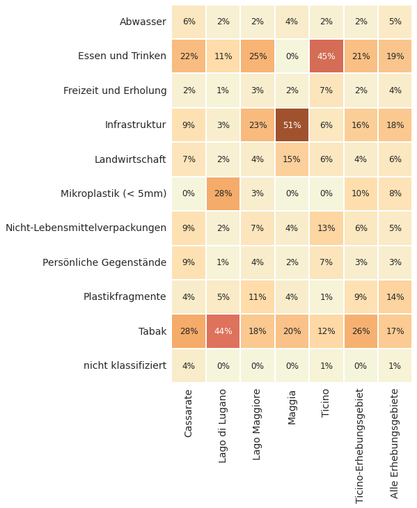

**Unten:** Ticino-Erhebungsgebiet Verwendungszweck der gefundenen Objekte Median p/100m. Fragmentierte Objekte, die nicht eindeutig identifiziert werden können, werden weiterhin nach ihrer Grösse klassifiziert.

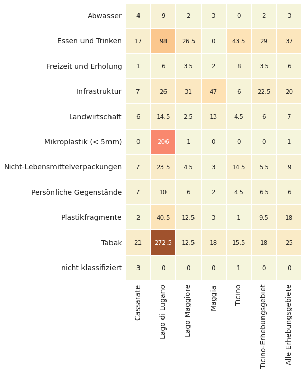

## Flüsse

**Links:** Ticino-Erhebungsgebiet Flüsse, 03.2020 bis 05.2021, n=6. Werte größer als 1'551 p/100m werden nicht gezeigt. **Rechts:** Zusammenfassende der Daten.

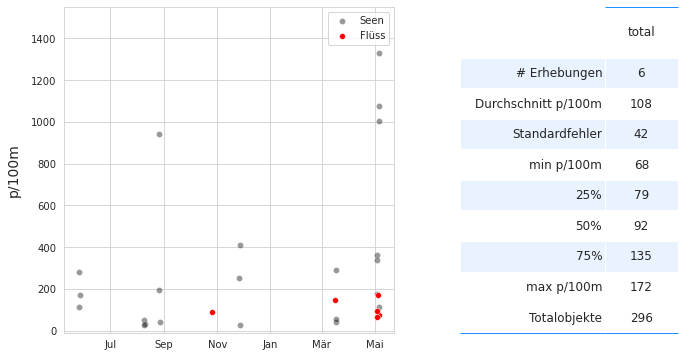

### Die an Flüssen am häufigsten gefundene Objekte

*Häufigste Objekte p/100m an Flüssen im Ticino-Erhebungsgebiet: Medianwert der Erhebung.*

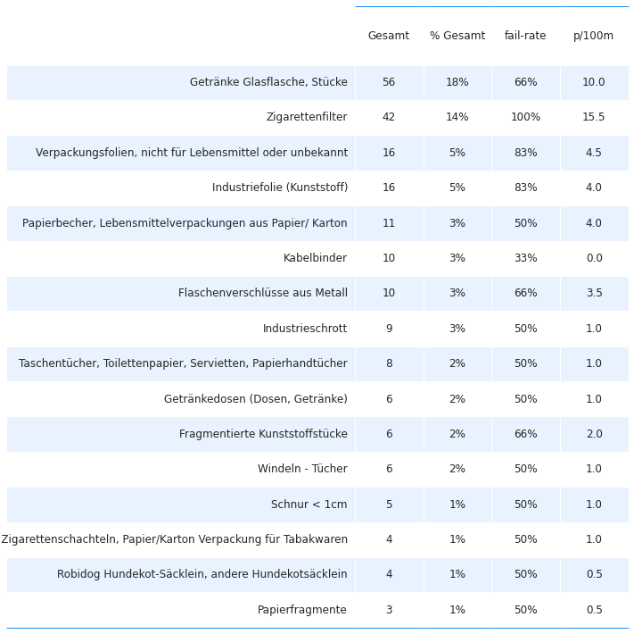

## Anhang

### Schaumstoffe und Kunststoffe nach Größe

Die folgende Tabelle enthält die Komponenten "Gfoam" und "Gfrags", die für die Analyse gruppiert wurden. Objekte, die als Schaumstoffe gekennzeichnet sind, werden als Gfoam gruppiert und umfassen alle geschäumten Polystyrol-Kunststoffe > 0,5 cm. Kunststoffteile und Objekte aus kombinierten Kunststoff- und Schaumstoffmaterialien > 0,5 cm werden für die Analyse als Gfrags gruppiert.

**Unten:** Fragmentierte und geschäumte Kunststoffe nach Größe im Ticino-Erhebungsgebiet, Median p/100m, Anzahl der gefundenen Stücke und Prozent der Gesamtmenge.

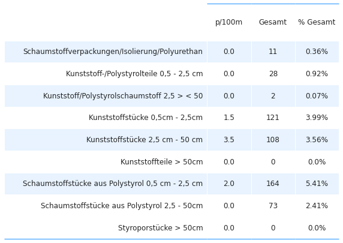

### Die Erhebungsorte

| Standort | latitude | longitude | Stadt |
| --- | --- | --- | --- |
| caprino | 45.987963 | 8.986241 | Lugano |
| foce-del-cassarate | 46.002411 | 8.961477 | Lugano |
| lido | 46.002004 | 8.962156 | Lugano |
| lugano-centro | 46.002627 | 8.950724 | Lugano |
| spiaggia-parco-ciani | 46.002510 | 8.960820 | Lugano |
| via-brunari-spiaggia | 46.202350 | 9.016910 | Bellinzona |
| golene-gudo | 46.170655 | 8.946657 | Bellinzona |
| isole-di-brissago-porto | 46.132760 | 8.735030 | Brissago |
| magadino-lido | 46.149349 | 8.855663 | Gambarogno |
| rivapiana | 46.172079 | 8.813255 | Minusio |
| via-mirasole-spiaggia | 46.199530 | 9.014930 | Bellinzona |
| sentiero-giro-del-golf-spiaggia | 46.145770 | 8.790430 | Ascona |
| vira-gambarogno | 46.143343 | 8.838759 | Gambarogno |
| canale-saleggi | 46.200625 | 9.015853 | Bellinzona |
| route-13 | 46.162521 | 8.782579 | Locarno |
| ascona-traghetto-spiaggia | 46.153882 | 8.768480 | Ascona |
| pacha-mama-gerra | 46.123473 | 8.783508 | Gambarogno |
| gerra-gambarogno | 46.123366 | 8.785786 | Gambarogno |
| san-nazzaro-gambarogno | 46.130443 | 8.798657 | Gambarogno |
| vira-spiaggia-left-of-river | 46.142900 | 8.838407 | Gambarogno |

### Inventar der Objekte

| code | Objekte | Gruppenname | Menge | % Gesamt | Fail-Pass |
| --- | --- | --- | --- | --- | --- |
| G27 | Zigarettenfilter | Tabak | 743 | 24.51 | 96 |
| G200 | Getränke Glasflasche, Stücke | Essen und Trinken | 274 | 9.04 | 85 |
| Gfrags | Fragmentierte Kunststoffstücke | Plastikfragmente | 259 | 8.55 | 85 |
| G112 | Industriepellets (Nurdles) | Mikroplastik (< 5mm) | 247 | 8.15 | 17 |
| Gfoam | Expandiertes Polystyrol | Infrastruktur | 237 | 7.82 | 57 |
| G30 | Snack-Verpackungen | Essen und Trinken | 130 | 4.29 | 71 |
| G67 | Industriefolie (Kunststoff) | Landwirtschaft | 80 | 2.64 | 82 |
| G941 | Verpackungsfolien, nicht für Lebensmittel oder... | Nicht-Lebensmittelverpackungen | 72 | 2.38 | 57 |
| G117 | Styropor < 5mm | Mikroplastik (< 5mm) | 65 | 2.14 | 32 |
| G74 | Schaumstoffverpackungen/Isolierung/Polyurethan | Infrastruktur | 64 | 2.11 | 67 |
| G178 | Flaschenverschlüsse aus Metall | Essen und Trinken | 54 | 1.78 | 50 |
| G89 | Kunststoff-Bauabfälle | Infrastruktur | 42 | 1.39 | 57 |
| G149 | Papierverpackungen | Nicht-Lebensmittelverpackungen | 36 | 1.19 | 14 |
| G921 | Keramikfliesen und Bruchstücke | Infrastruktur | 34 | 1.12 | 35 |
| G10 | Lebensmittelbehälter zum einmaligen Gebrauch a... | Essen und Trinken | 30 | 0.99 | 32 |
| G153 | Papierbecher, Lebensmittelverpackungen aus Pap... | Essen und Trinken | 27 | 0.89 | 28 |
| G177 | Verpackungen aus Aluminiumfolie | Essen und Trinken | 26 | 0.86 | 39 |
| G95 | Wattestäbchen | Abwasser | 23 | 0.76 | 39 |
| G923 | Taschentücher, Toilettenpapier, Servietten, Pa... | Persönliche Gegenstände | 22 | 0.73 | 39 |
| G21 | Getränke-Deckel, Getränkeverschluss | Essen und Trinken | 20 | 0.66 | 28 |
| G156 | Papierfragmente | Nicht-Lebensmittelverpackungen | 18 | 0.59 | 42 |
| G152 | Papier &Karton;Zigarettenschachteln, Papier/Ka... | Tabak | 18 | 0.59 | 28 |
| G66 | Umreifungsbänder; Hartplastik für Verpackung f... | Infrastruktur | 17 | 0.56 | 32 |
| G186 | Industrieschrott | Infrastruktur | 17 | 0.56 | 25 |
| G25 | Tabak; Kunststoffverpackungen, Behälter | Tabak | 16 | 0.53 | 35 |
| G73 | Gegenstände aus Schaumstoff & Teilstücke (nich... | Freizeit und Erholung | 16 | 0.53 | 28 |
| G93 | Kabelbinder | Infrastruktur | 15 | 0.49 | 17 |
| G3 | Einkaufstaschen, Shoppingtaschen | Nicht-Lebensmittelverpackungen | 15 | 0.49 | 21 |
| G137 | Kleidung, Handtücher und Lappen | Persönliche Gegenstände | 15 | 0.49 | 17 |
| G98 | Windeln - Tücher | Abwasser | 15 | 0.49 | 35 |

[output cut: 94 more lines]